# DWARF Fluorescence PARAFAC

Cathrine Brecke Gundersen (NIVA)

3/23/2022

### Introduction

- first attempt to PARAFAC the fluorescence EEM from the DWARF project
- Aim: can we distinguish anthropogenic from natural DOM?

### Step 1. Upload data and exclude samples that do not belong to the project

- Exclude the following samples that do not belong to the DWARF project

```
## $sample
##   [1] "v2021135"     "v2021136"     "v2021137"     "v2021138"     "v2021139"
##   [6] "v2021140"     "v2021141"     "v2021142"     "v2021143"     "v2021144"
##  [11] "v2021145"     "v2021146"     "v2021147"     "v2021148"     "v2021149"
##  [16] "v2021150"     "v2022117"     "v2022118"     "v2022119"     "v2022120"
##  [21] "v2022121"     "v2022122"     "v2022123"     "v2022124"     "v2022125"
##  [26] "v2022126"     "v2022127"     "v2022128"     "v2022129"     "v2022130"
##  [31] "v2022153"     "v2022154"     "v2022155"     "v2022156"     "v2022157"
##  [36] "v2022158"     "v2022159"     "v2022160"     "v2022161"     "v2022164"
##  [41] "v2022165"     "v20212837"    "v20212838"    "v20212839"    "v20212840"
##  [46] "v20212841"    "v20212842"    "v20212843"    "v20212844"    "v20212845"
##  [51] "v20212846"    "v20212847"    "v20213112"    "v20213113"    "v20213114"
##  [56] "v20213142"    "v20213143"    "v20213144"    "v20213223"    "v20213224"
##  [61] "v20213225"    "v20213226"    "v20213231"    "v20213232"    "v20213234"
##  [66] "v20213276"    "v20213277"    "v20213278"    "v20213279"    "v20213280"
##  [71] "v20213281"    "v20213371"    "v20213372"    "v20213373"    "v020213141NF"
##  [76] "v020213142NF" "v020213143NF" "v020213144NF" "v020213222NF" "v020213223NF"
##  [81] "v020213224NF" "v020213225NF" "v20213226NF"  "v20213233NF"  "v20213234NF"
##  [86] "v20213275NF"  "v20213276NF"  "v20213277NF"  "v20213278NF"  "v20213279NF"
##  [91] "v20213280NF"  "v20213281NF"  "v20213370NF"  "v20213371NF"  "v20213372NF"
##  [96] "v20213373NF"  "v20213141NF"  "v20213142NF"  "v20213143NF"  "v20213144NF"
## [101] "v20213222NF"  "v20213223NF"  "v20213224NF"  "v20213225NF"
```

### Step 3. First PARAFAC attempt. Lower “resolution”

Aim: obtain the correct number of components

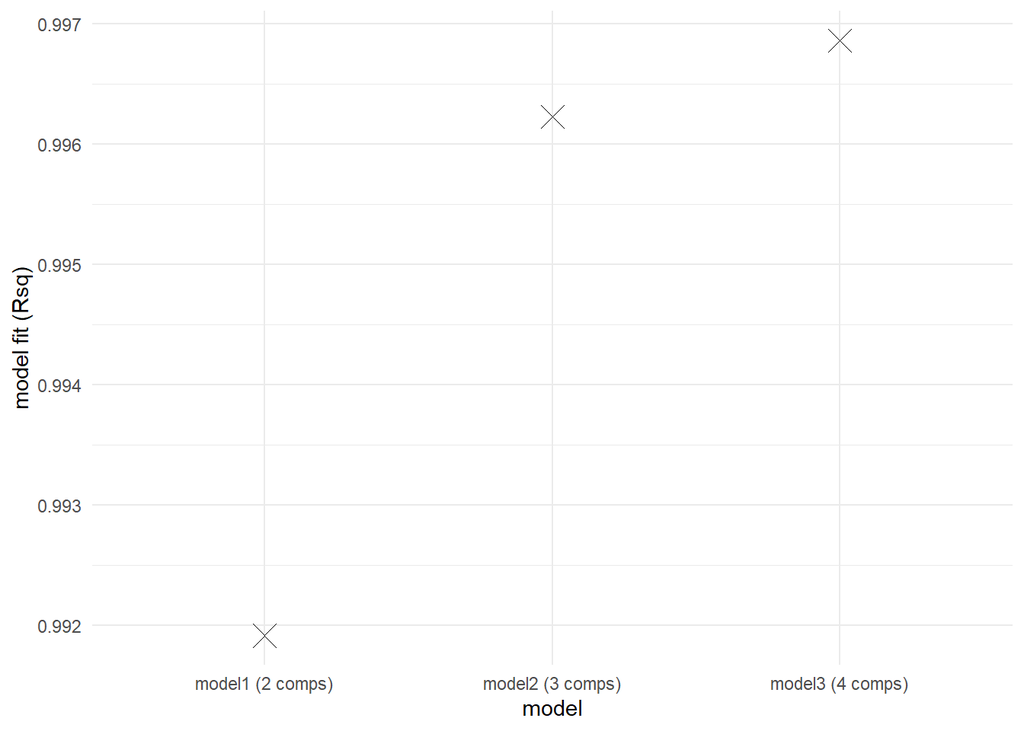

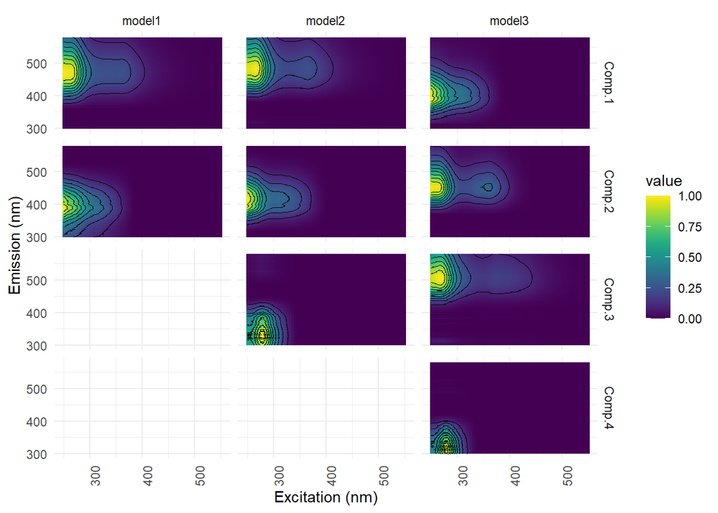

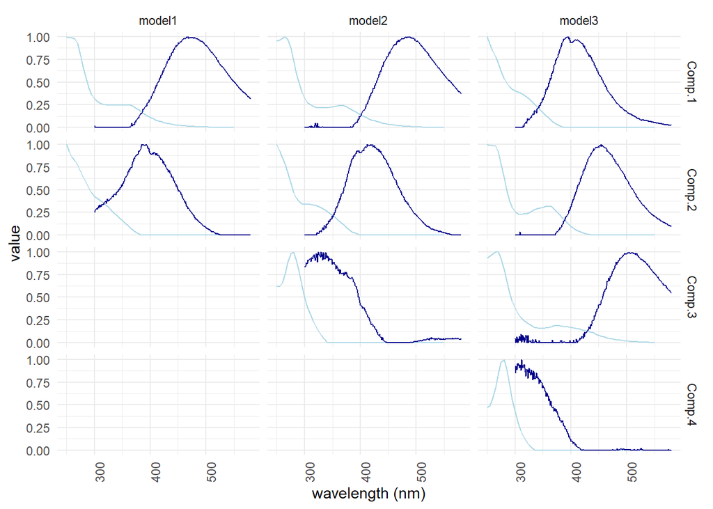

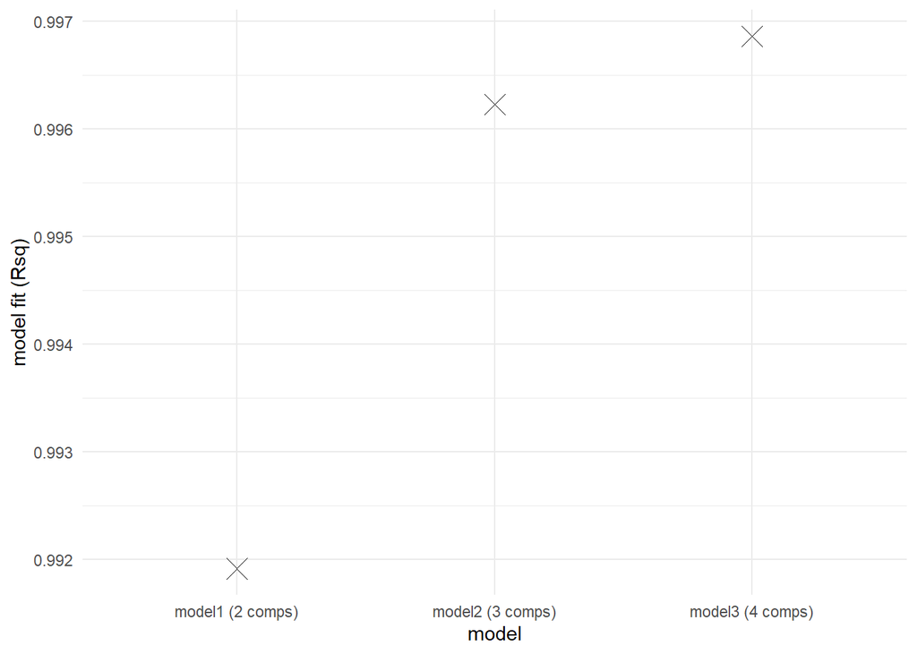

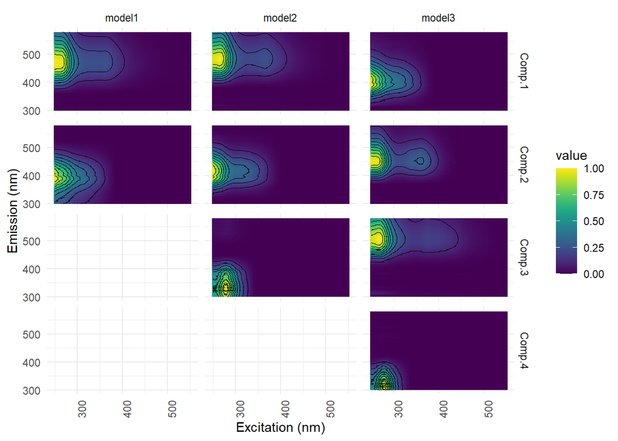

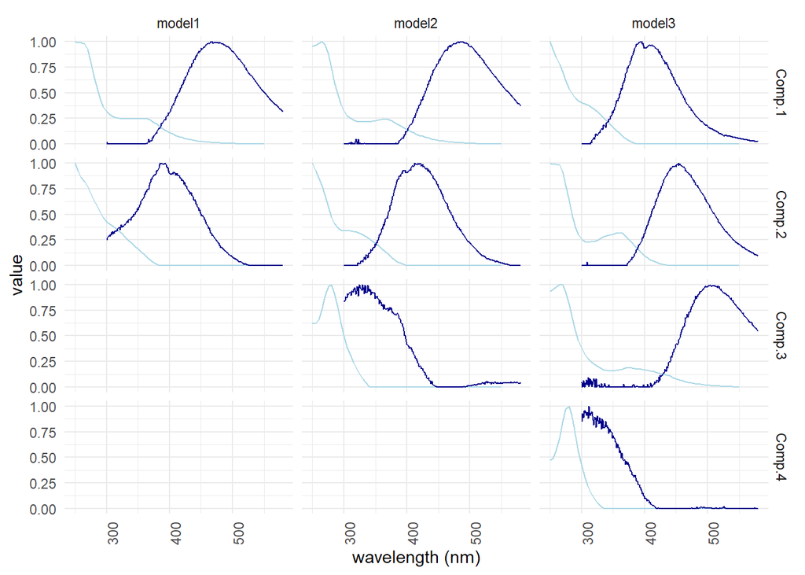

```r
 #10) First attempt PARAFAC model
# minimum and maximum of numbers of components
# parameter settings from stardom guideline
cores <- detectCores(logical = FALSE)
dim_min <- 2
dim_max <- 4

nstart <- 25 # number of similar models from which best is chosen
maxit = 5000 # maximum number of iterations in PARAFAC analysis
ctol <- 10^-6 # tolerance in PARAFAC analysis

# 11) calculating PARAFAC models, one for each number of components
#using non-negative constraints
pf1 <- eem_parafac(eem_list2, comps = seq(dim_min,dim_max), normalise = FALSE, const = c("nonneg", "nonneg", "nonneg"), maxit = maxit, nstart = nstart, ctol = ctol, cores = cores)

# 12) rescale B and C modes to a maximum fluorescence of 1 for each component
pf1n <- lapply(pf1, eempf_rescaleBC, newscale = "Fmax")
#Compare the different models in plot
eempf_compare(pf1n, contour = TRUE)
```

- the fit of the models is good (r2), very small increase going from 3 to 4 components - the excitation and emission bands do not look perfect, worsen for every added component - strong correlation between the components. Therefore, data is normalised. Doesnt help a lot though. - Interestingly, the third component looks identical to 1000Lakes assumed contamination

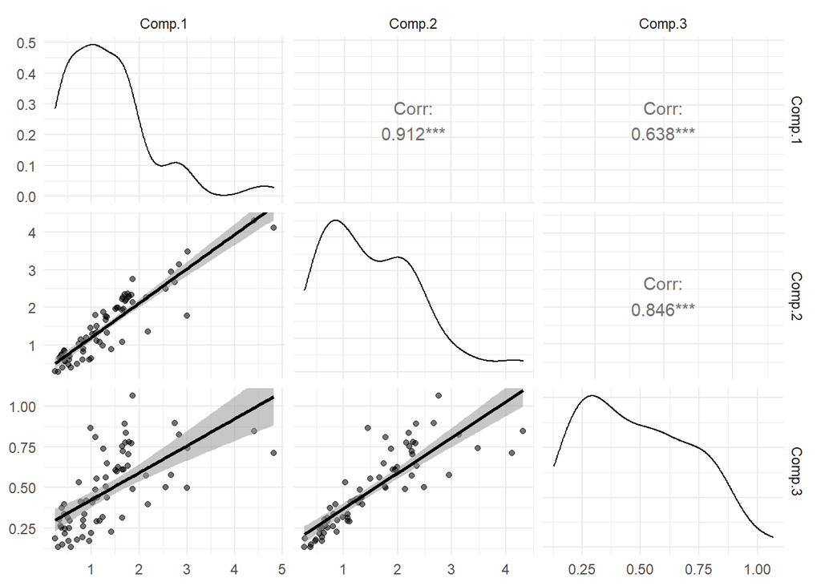

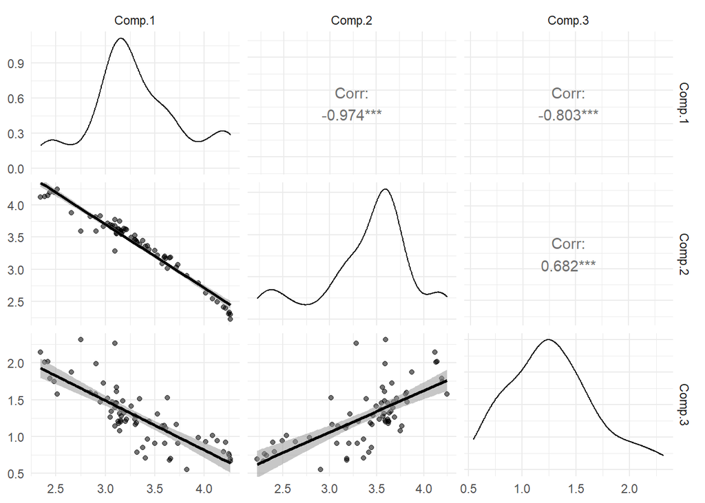

### Step 4. Evaluate extreme samples/wavelengths

- sometimes, extreme samples or emission/excitation wavelengths can be excluded from the sample set prior to making the PARAFAC model
- dont appear to be any strong outliers (value from 0 to 1)
- confirmed to keep samples

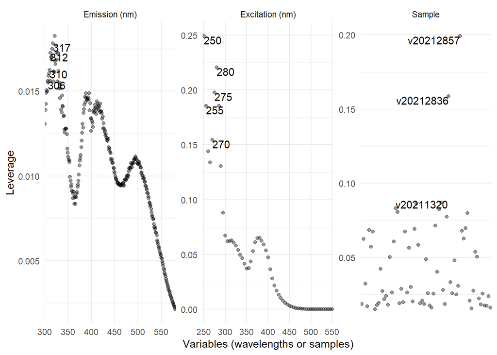

### Step 5. Re-run PARAFAC model with increased “resolution”

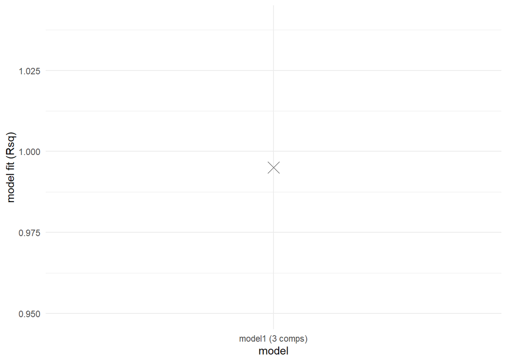

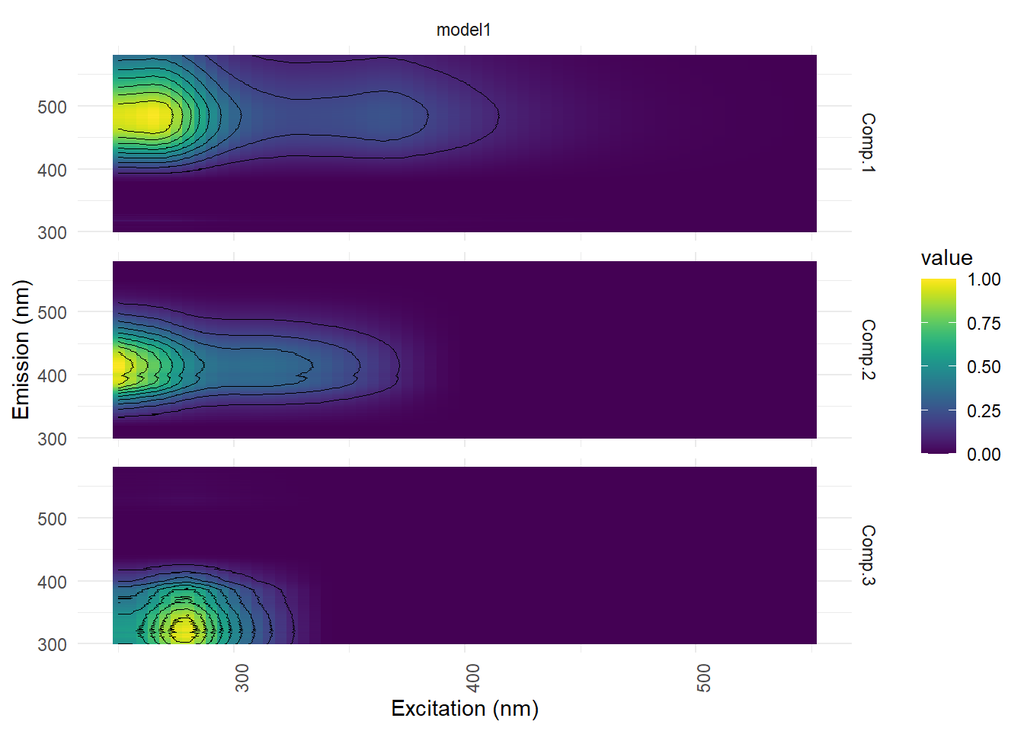

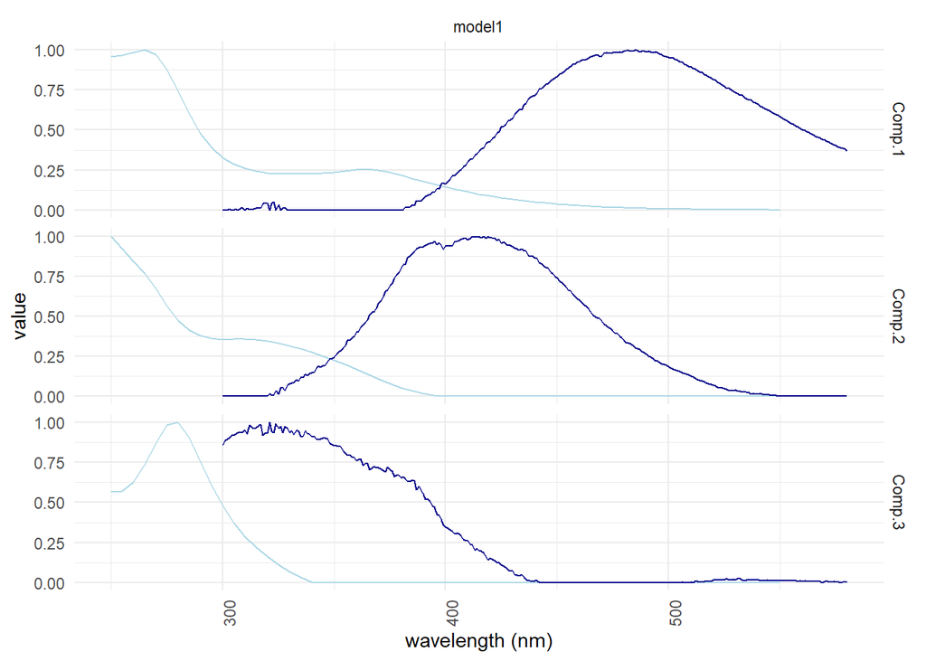

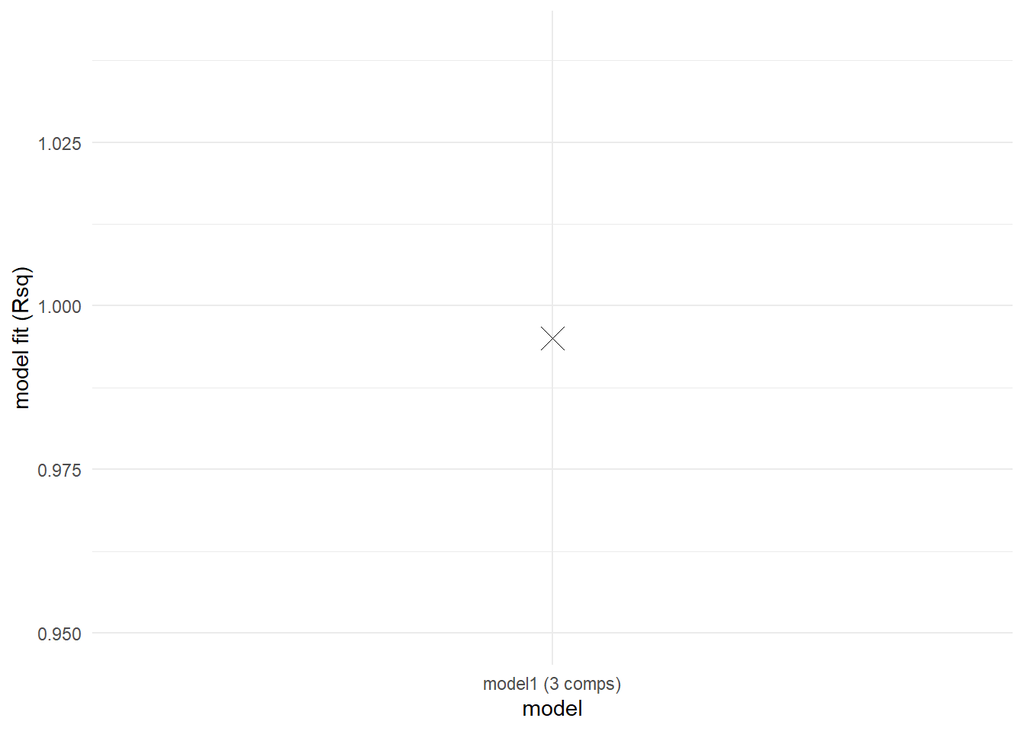

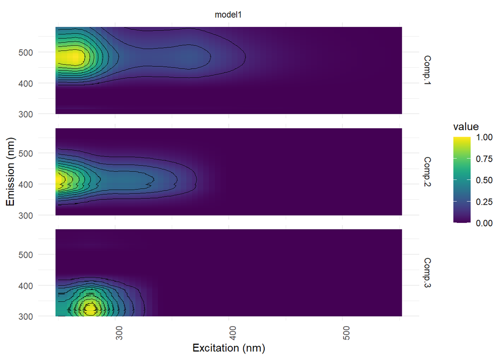

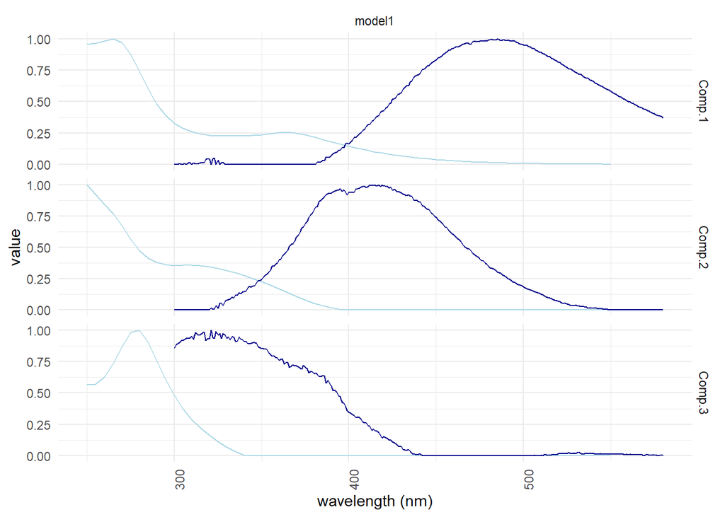

### Step 6. Model checking

- several options are available, with their different advantagous and disadvantagous
- some subjectivity is involved

```
## Calculated models:  50
## Converging models:  30
## Not converging Models, iteration limit reached:  0
## Not converging models, other reasons:  20
## Best SSE:  8151.816
## Summary of SSEs of converging models:
##    Min. 1st Qu.  Median    Mean 3rd Qu.    Max.
##    8152    8152    8152    8152    8152    8152
```

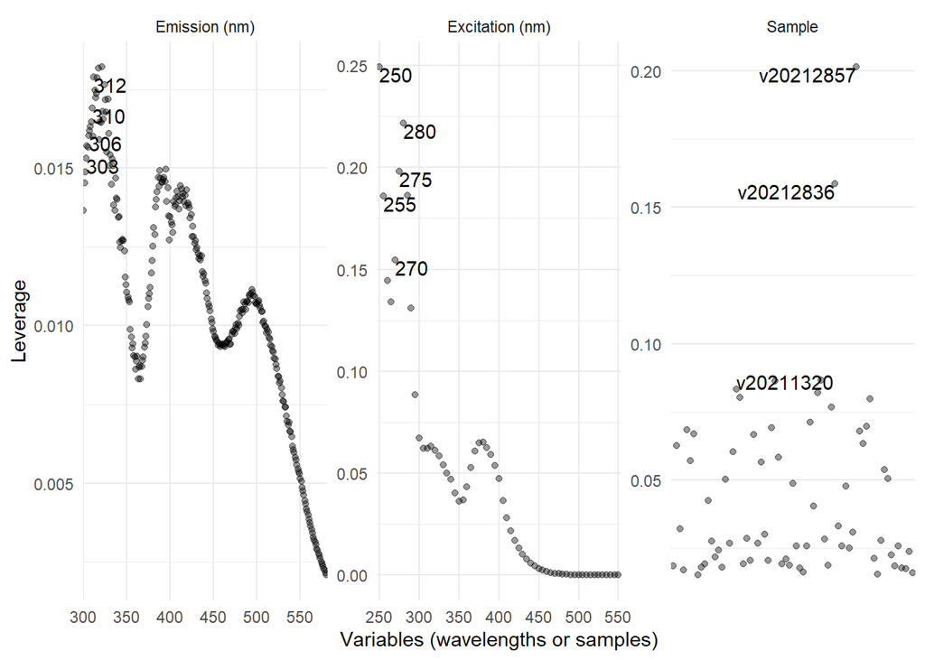

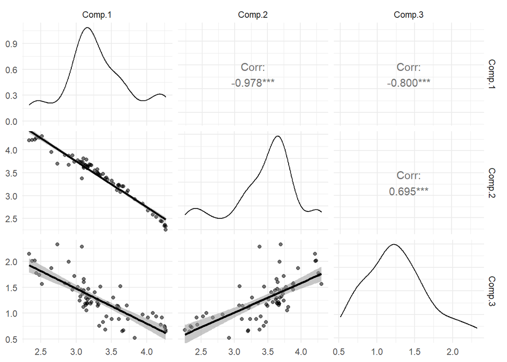

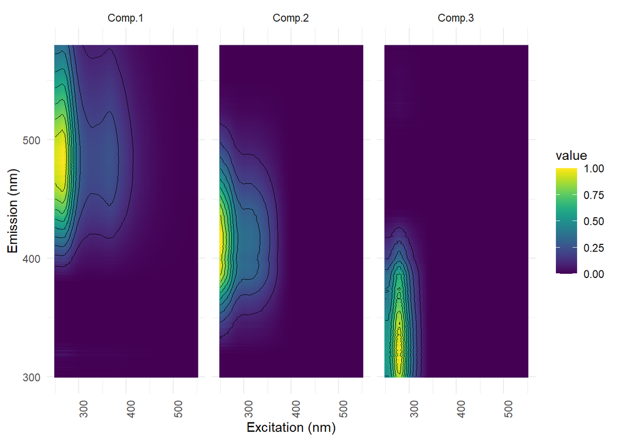

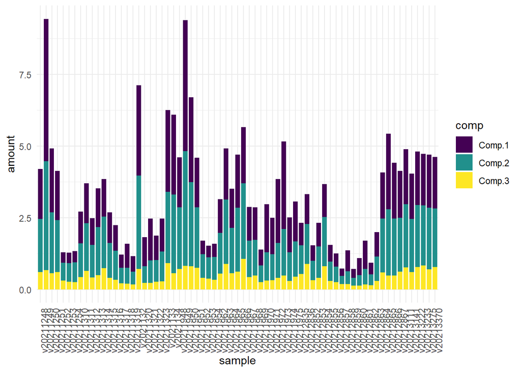

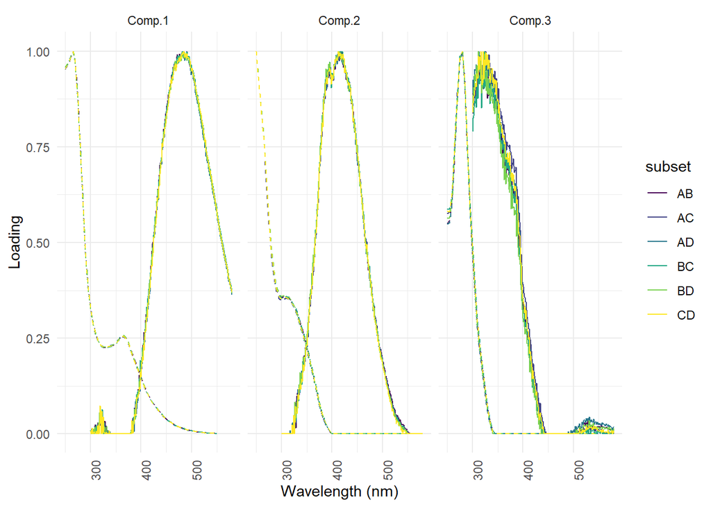

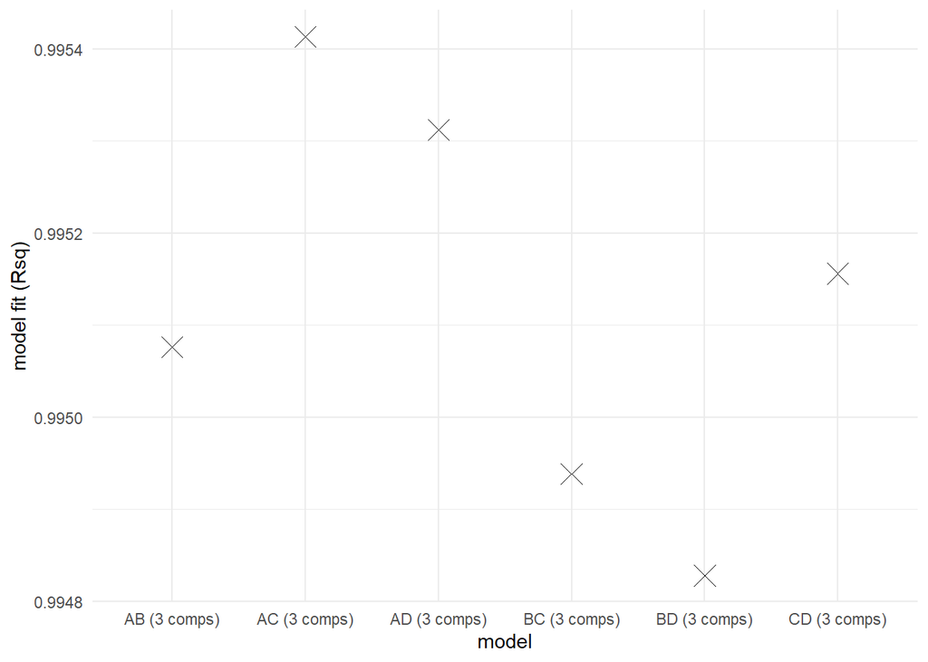

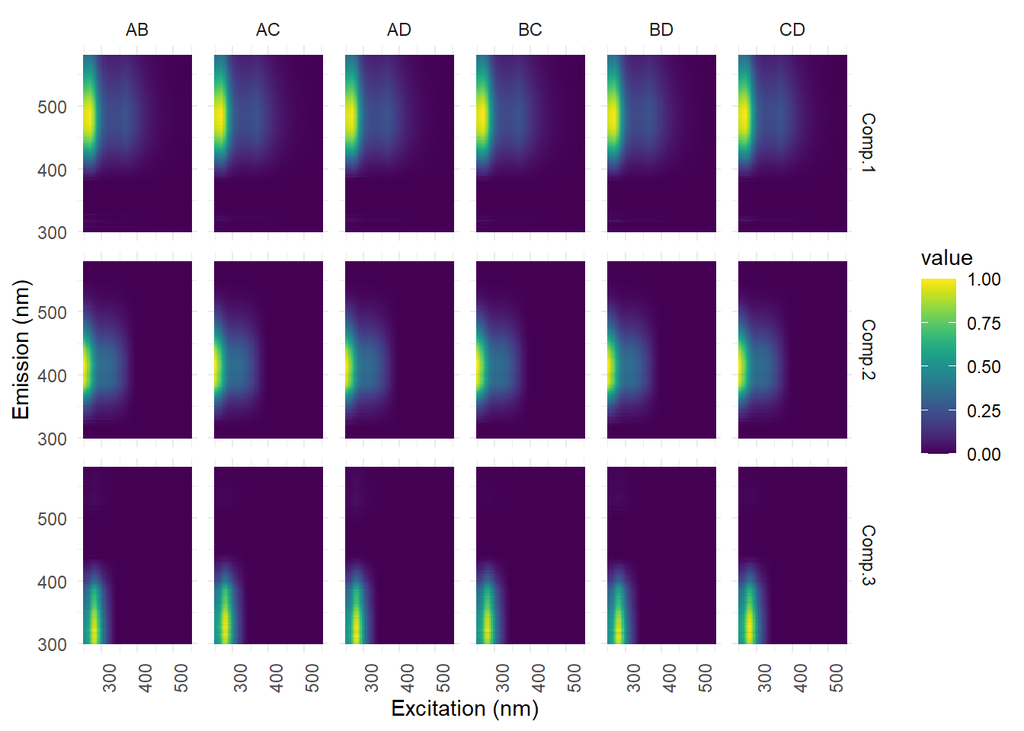

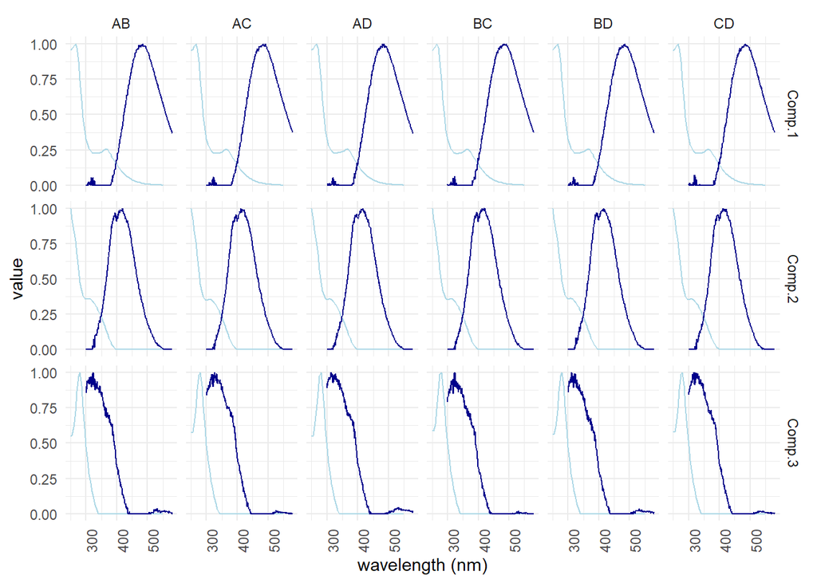

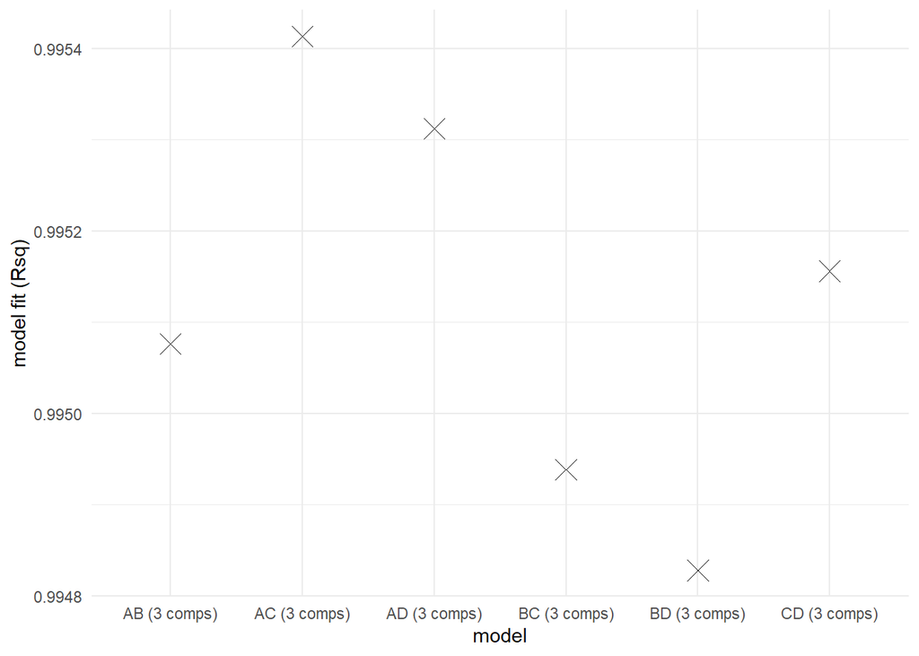

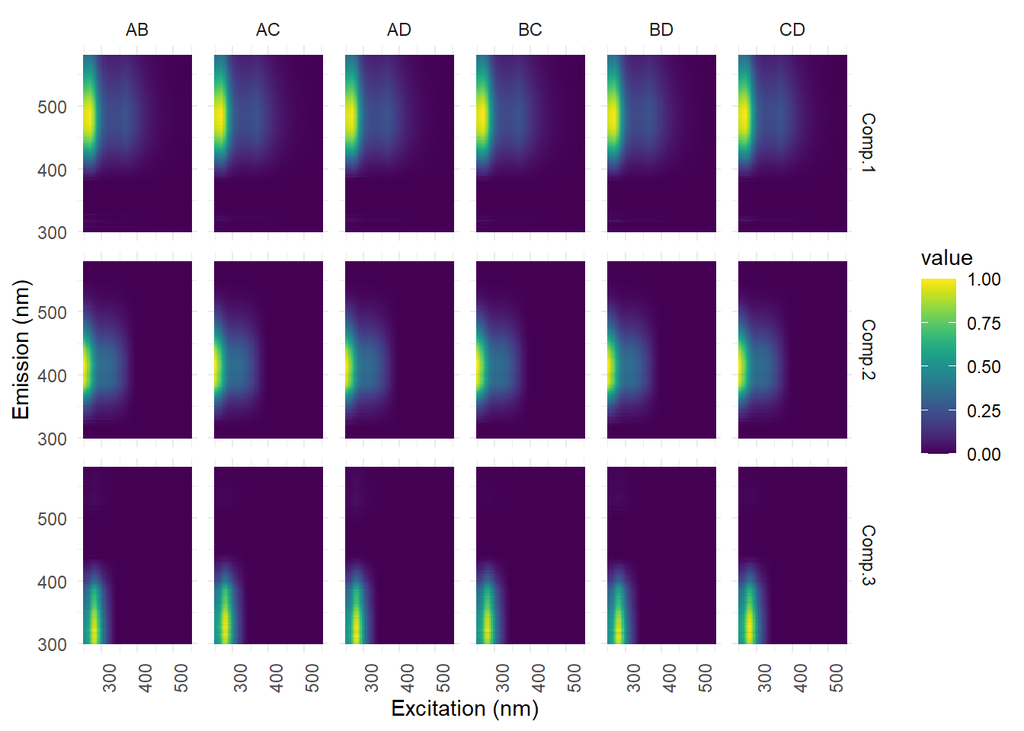

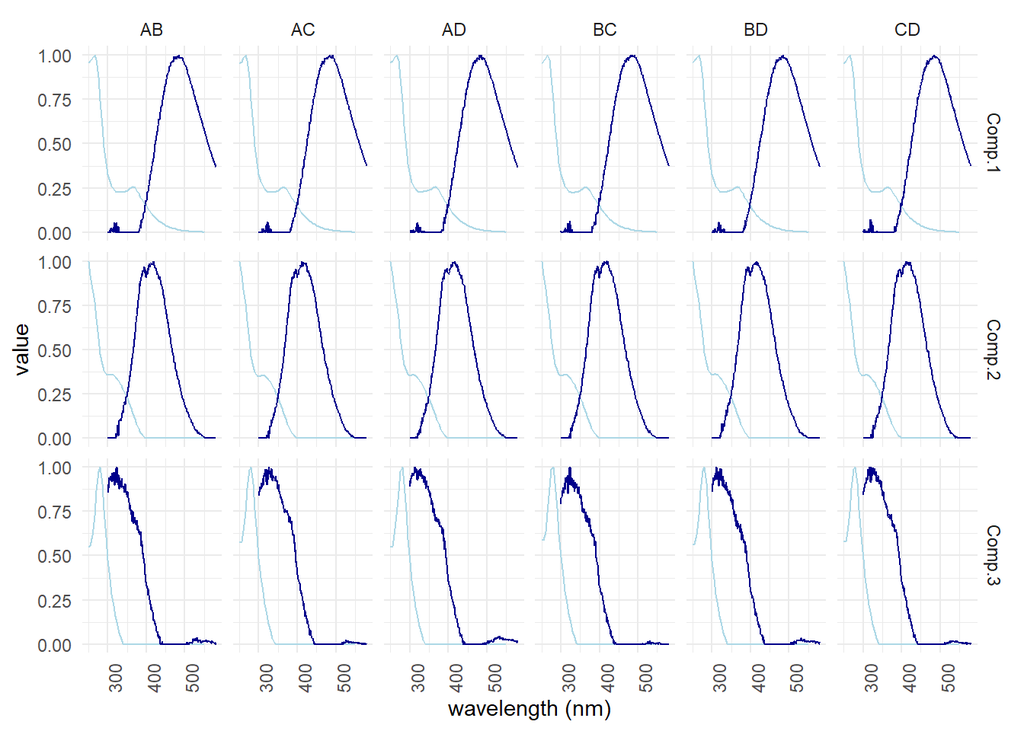

```
##   component   comb    tcc_em    tcc_ex
## 1    Comp.1 ABvsCD 0.9999947 0.9997401
## 2    Comp.1 ACvsBD 0.9999834 0.9998917
## 3    Comp.1 ADvsBC 0.9999831 0.9997972
## 4    Comp.2 ABvsCD 0.9999903 0.9996519
## 5    Comp.2 ACvsBD 0.9998971 0.9996295
## 6    Comp.2 ADvsBC 0.9999119 0.9997770
## 7    Comp.3 ABvsCD 0.9998841 0.9992053
## 8    Comp.3 ACvsBD 0.9998873 0.9964544
## 9    Comp.3 ADvsBC 0.9996800 0.9988165
```

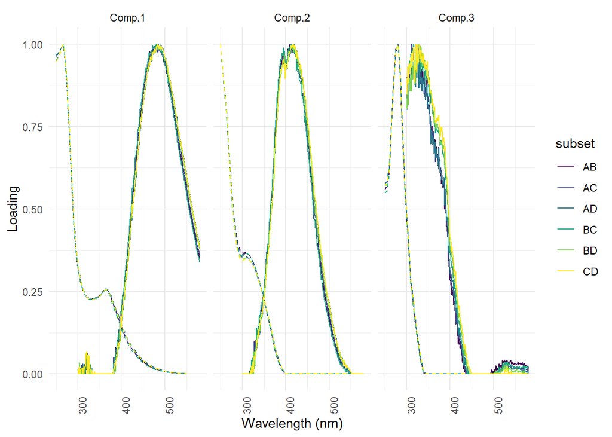

```
##   component   comb    tcc_em    tcc_ex
## 1    Comp.1 ABvsCD 0.9998195 0.9990525
## 2    Comp.1 ACvsBD 0.9999049 0.9991687
## 3    Comp.1 ADvsBC 0.9997175 0.9979067
## 4    Comp.2 ABvsCD 0.9996723 0.9976582
## 5    Comp.2 ACvsBD 0.9998602 0.9991190
## 6    Comp.2 ADvsBC 0.9996536 0.9971573
## 7    Comp.3 ABvsCD 0.9997945 0.9940584
## 8    Comp.3 ACvsBD 0.9999280 0.9951647
## 9    Comp.3 ADvsBC 0.9997804 0.9986239
```

```
## [1] 0.26429514 0.14592836 0.02834082
```

### Step 6. Created model is exported to OpenFluor to compare with other studies and identify the components

From OpenFluor the following can be linked to the model components: C1: Humic-material, larger-sized, characteristic of soil, sediment and freshwater environments, recalcitrant soil or plant material, highly resistant to microbial degradation but suspictible to photodecay (https://doi.org/10.1016/j.geoderma.2017.06.029), similar to soil-fulvic material (10.1080/00785236.2003.10409512) C2: Humic-material, mid-sized, characteristic of soil, sediment and freshwater environments, recalcitrant soil or plant material, highly resistant to microbial degradation but suspictible to photodecay (https://doi.org/10.1016/j.geoderma.2017.06.029) C3: protein-like material (tryptophane/tyrosine), often linked to anthropogenic disctrubances (10.1890/12-0825.1)